# Rapport - Données manquantes

#### Nom et Prénom des étudiants du groupe :

```
- Nom : Prénom : REAL Philippe
- Nom : Prénom : GUYONVARCH Alexis
```

### 1. Introduction

Présentation des données et objectifs de l’étude https://www.kaggle.com/uciml/pima-indians-diabetes-database

#### 1.1 Contexte

Le jeu de données provient de l’Institut national du diabete, des maladies digestives et rénales. Il rend possible la prédiction de la pathologie, en l’espèce le diabète, pour le patient à partir d’analyses inclues dans le jeu de données. Dans l’extraction, les patients sont des femmes et issues de la commmunauté des indiens Pima.

#### 1.2 Description des colonnes

- npreg : Number of times pregnant - Nombre de grossesses
- glu : GlucosePlasma 2 hours in an oral glucose tolerance test - Concentration de glucose dans le sang
- bp : BloodPressureDiastolic - Pression sanguine (mm Hg)
- skin : SkinThicknessTriceps - Epaisseur de la peau (mm)
- Insuline : Insulin 2- Hour serum insuline - Taux d’insuline présent dans le sang (mu U/ml)
- bmi : BMIBody mass index - Indice de masse corporelle (poids en kg/(taille en m)élevée au carré)
- ped : Diabetes Pedigree Function Diabetes pedigree function - Antécédent de diabète sucrégénétique
- age : Age (years)
- type : Outcome Class variable - Variable réponse binaire (0/1)

#### 1.3 Objectifs

Objectif : prédire si l’individu a ou non le diabète. Préalablement, il s’agi de compléter les données manquante par imputation.

#### 1.4 Chargement des donnés - Résumé

```r
rm(list=ls())

knitr::opts_chunk$set(
  echo = TRUE,
  warning = FALSE,
  message = FALSE,
  fig.align = "center",
  fig.retina = 2,
  fig.width = 10,
  cache=TRUE,
  cache.lazy = FALSE
  )
# Librairies
library(MASS);
library(missMDA);
library(mice);
library(VIM)
library(FactoMineR)
library(ggplot2)
library(factoextra)
library(corrplot)
library(leaps)
library(psych)
library(sampSurf)
#setwd("D:/R exercices/DONNEES MANQUANTES/Projet")
data<-read.table(file="Pima_DataWithNA.txt",sep=";" ,header=T, na.strings = "NA")
# Description du jeu de données
describe(data[,-1])
```

|  | vars | n | mean | sd | median | trimmed | mad | min | max | range | skew | kurtosis | se |
| --- | --- | --- | --- | --- | --- | --- | --- | --- | --- | --- | --- | --- | --- |
| npreg | 1 | 768 | 3.8450521 | 3.3695781 | 3.0000 | 3.4610390 | 2.9652000 | 0.000 | 17.00 | 17.000 | 0.8981549 | 0.1421840 | 0.12158918 |
| glu | 2 | 763 | 121.6867628 | 30.5356411 | 117.0000 | 119.6579378 | 29.6520000 | 44.000 | 199.00 | 155.000 | 0.5289026 | -0.2901980 | 1.10546443 |
| bp | 3 | 733 | 72.4051842 | 12.3821582 | 72.0000 | 72.2896082 | 11.8608000 | 24.000 | 122.00 | 98.000 | 0.1336042 | 0.8861549 | 0.45734545 |
| skin | 4 | 541 | 29.1534196 | 10.4769824 | 29.0000 | 28.8752887 | 10.3782000 | 7.000 | 99.00 | 92.000 | 0.6867941 | 2.8755795 | 0.45044065 |
| Insuline | 5 | 394 | 155.5482234 | 118.7758552 | 125.0000 | 135.3196203 | 81.5430000 | 14.000 | 846.00 | 832.000 | 2.1499958 | 6.2277542 | 5.98384114 |
| bmi | 6 | 757 | 32.4574637 | 6.9249883 | 32.3000 | 32.1105437 | 6.8199600 | 18.200 | 67.10 | 48.900 | 0.5916179 | 0.8396070 | 0.25169298 |
| ped | 7 | 768 | 0.4718763 | 0.3313286 | 0.3725 | 0.4215536 | 0.2483355 | 0.078 | 2.42 | 2.342 | 1.9124179 | 5.5285389 | 0.01195579 |
| age | 8 | 768 | 33.2408854 | 11.7602315 | 29.0000 | 31.5438312 | 10.3782000 | 21.000 | 81.00 | 60.000 | 1.1251880 | 0.6217269 | 0.42436080 |
| type | 9 | 768 | 0.3489583 | 0.4769514 | 0.0000 | 0.3116883 | 0.0000000 | 0.000 | 1.00 | 1.000 | 0.6325383 | -1.6019762 | 0.01721050 |

```r
# Elements de cadrage sur les données manquantes
pMiss <- function(x){round(sum(is.na(x))/length(x)*100,digits=1)}
stat.miss <- apply(data[,-1],2,pMiss)
print('Pourcentage de données manquantes par variable')
```

```
## [1] "Pourcentage de données manquantes par variable"
```

```r
print('-----------------------------------------------------------------------------')
```

```
## [1] "-----------------------------------------------------------------------------"
```

```r
stat.miss
```

```
##    npreg      glu       bp     skin Insuline      bmi      ped      age
##      0.0      0.7      4.6     29.6     48.7      1.4      0.0      0.0
##     type
##      0.0
```

- Traitement des données

Suppression de la 1ère colonne comprenant les identifants. La colonne insuline est, dans l’immédiat, conservée en dépit de la part importante de données manquantes : 48.7 %.

```r
tab_Pima1<-data[,-1]
#tab_Pima1<-tab_Pima1[,-5]# La colonne insuline est dans l'immédiat conservée
maxDim<-9 #8 si on décide de supprimer la colonne insuline
data_Pima1<-as.data.frame.matrix(tab_Pima1)
data_Pima1$type <- as.logical(data_Pima1$type)
dataPima<-data_Pima1[,1:maxDim]
dataPima<- as.data.frame(dataPima)

describe(dataPima[,-9])
```

|  | vars | n | mean | sd | median | trimmed | mad | min | max | range | skew | kurtosis | se |
| --- | --- | --- | --- | --- | --- | --- | --- | --- | --- | --- | --- | --- | --- |
| npreg | 1 | 768 | 3.8450521 | 3.3695781 | 3.0000 | 3.4610390 | 2.9652000 | 0.000 | 17.00 | 17.000 | 0.8981549 | 0.1421840 | 0.12158918 |
| glu | 2 | 763 | 121.6867628 | 30.5356411 | 117.0000 | 119.6579378 | 29.6520000 | 44.000 | 199.00 | 155.000 | 0.5289026 | -0.2901980 | 1.10546443 |
| bp | 3 | 733 | 72.4051842 | 12.3821582 | 72.0000 | 72.2896082 | 11.8608000 | 24.000 | 122.00 | 98.000 | 0.1336042 | 0.8861549 | 0.45734545 |
| skin | 4 | 541 | 29.1534196 | 10.4769824 | 29.0000 | 28.8752887 | 10.3782000 | 7.000 | 99.00 | 92.000 | 0.6867941 | 2.8755795 | 0.45044065 |
| Insuline | 5 | 394 | 155.5482234 | 118.7758552 | 125.0000 | 135.3196203 | 81.5430000 | 14.000 | 846.00 | 832.000 | 2.1499958 | 6.2277542 | 5.98384114 |
| bmi | 6 | 757 | 32.4574637 | 6.9249883 | 32.3000 | 32.1105437 | 6.8199600 | 18.200 | 67.10 | 48.900 | 0.5916179 | 0.8396070 | 0.25169298 |
| ped | 7 | 768 | 0.4718763 | 0.3313286 | 0.3725 | 0.4215536 | 0.2483355 | 0.078 | 2.42 | 2.342 | 1.9124179 | 5.5285389 | 0.01195579 |
| age | 8 | 768 | 33.2408854 | 11.7602315 | 29.0000 | 31.5438312 | 10.3782000 | 21.000 | 81.00 | 60.000 | 1.1251880 | 0.6217269 | 0.42436080 |

- Les différentes catégories de données manquantes sont “taguées” en vue d’analyses ultérieures. La description deux à deux des patterns est effectuée avec avec la fonction md.pairs() du package mice qui nous permet déjà de mettre en lumière les 10 combinaisons du jeu de données parmi les 28 possibles.

```r
##Tager des données qui seront ultérieurement complétées
attach(dataPima)
comb.miss <- md.pairs(dataPima[,2:6])
print("Combinaisons 2 à 2 des données manquantes")
```

```
## [1] "Combinaisons 2 à 2 des données manquantes"
```

```r
comb.miss$mm
```

```
##          glu bp skin Insuline bmi
## glu        5  0    0        4   0
## bp         0 35   33       35   7
## skin       0 33  227      227   9
## Insuline   4 35  227      374  10
## bmi        0  7    9       10  11
```

```r
glu.na <- row.names(dataPima[is.na(glu),0])
bp.na<-row.names(dataPima[is.na(bp),0])
skin.na<-row.names(dataPima[is.na(skin),0])
bmi.na<-row.names(dataPima[is.na(bmi),0])

#Combinaisons glu
glu.only<-  row.names(dataPima[which(is.na(glu) & !is.na(bmi) & !is.na(skin) & !is.na(bp) & !is.na(Insuline)),0])
glu.Insuline <-  row.names(dataPima[which(is.na(glu) & is.na (Insuline)),0])
#Combinaisons bp
#bp.only<-  row.names(dataPima[which(is.na(bp) & !is.na(skin) & !is.na(glu) & !is.na(bmi)& !is.na(Insuline)),0]) # vide
#bp.skin <-  row.names(dataPima[which(is.na(bp) & is.na (skin) &  !is.na(bmi) & !is.na(Insuline) & !is.na(glu)),0])# vide
bp.Insuline <- row.names(dataPima[which(is.na(bp) & is.na (Insuline) & !is.na(skin) & !is.na(bmi) & !is.na(glu)),0])
#bp.bmi <- row.names(dataPima[which(is.na(bp) & is.na (bmi) & !is.na(skin) & !is.na(Insuline) & !is.na(glu)),0])#vide
bp.skin.Insuline <- row.names(dataPima[which(is.na(bp) & is.na (Insuline) & is.na(skin) & !is.na(bmi) & !is.na(glu)),0])
#bp.skin.bmi <- row.names(dataPima[which(is.na(bp) & is.na (bmi) & is.na(skin) & !is.na(Insuline) & !is.na(glu)),0])#vide
bp.skin.Insuline.bmi <- row.names(dataPima[which(is.na(bp) & is.na (bmi) & is.na(skin) & is.na(Insuline) & !is.na(glu)),0])
#Combinaisons skin
#skin.only <-row.names(dataPima[which(is.na(skin) & !is.na(bp) & !is.na(bmi) & !is.na(glu) & !is.na(Insuline)),0])#vide
skin.Insuline<- row.names(dataPima[which(is.na(skin) & is.na(Insuline) & !is.na(bmi) & !is.na(glu) & !is.na(bp)),0])
#skin.bmi <- row.names(dataPima[which(is.na(skin) & is.na (bmi) & !is.na(glu) & !is.na(bp) & !is.na(Insuline)),0])"vide
skin.bmi.Insuline <- row.names(dataPima[which(is.na(skin) & is.na (bmi) & is.na(Insuline) & !is.na(bp) & !is.na(glu)),0])
#Combinaisons bmi
bmi.only<-  row.names(dataPima[which(is.na(bmi) & !is.na(skin) & !is.na(bp) & !is.na(glu) &  !is.na(Insuline)),0])
bmi.Insuline<- row.names(dataPima[which(is.na(bmi) & is.na(Insuline) & !is.na(skin) & !is.na(glu) & !is.na(bp)),0])
#Combinaisons Insuline
Insuline.only <- row.names(dataPima[which(is.na(Insuline) & !is.na(bp) & !is.na(bmi) & !is.na(skin) & !is.na(glu)),0])
#skin.bmi.Insuline.bp.glu <- row.names(dataPima[which(is.na(skin) & is.na (bmi) & is.na(Insuline) & is.na(bp) & is.na(glu)),0])#vide

nb.rows<-nrow(dataPima)
missingCateg <- replicate(nb.rows,0)
dataPima.MissingCateg <- cbind(dataPima,missingCateg)
dataPima.MissingCateg$missingCateg <- as.integer(dataPima.MissingCateg$missingCateg)

data<-as.data.frame(dataPima.MissingCateg)

data[Insuline.only,"missingCateg"]=1
data[bmi.only,"missingCateg"]=2
data[glu.only,"missingCateg"]=3
data[bmi.Insuline,"missingCateg"]=4
data[bp.Insuline,"missingCateg"]=5
data[bp.skin.Insuline,"missingCateg"]=6
data[bp.skin.Insuline.bmi,"missingCateg"]=7
data[glu.Insuline,"missingCateg"]=8
data[skin.Insuline,"missingCateg"]=9
data[skin.bmi.Insuline,"missingCateg"]=10
data$missingCateg <- factor(as.integer(data$missingCateg),levels=c(0,1,2,3,4,5,6,7,8,9,10),
labels=c("No-Missing","Insuline.only","bmi.only","glu.only","bmi.Insuline","bp.Insuline","bp.skin.Insuline","bp.skin.Insuline.bmi","glu.Insuline","skin.Insuline","skin.bmi.Insuline"))

head(data)
```

|  | npreg | glu | bp | skin | Insuline | bmi | ped | age | type | missingCateg |
| --- | --- | --- | --- | --- | --- | --- | --- | --- | --- | --- |
| 1 | 6 | 148 | 72 | 35 | NA | 33.6 | 0.627 | 50 | TRUE | Insuline.only |
| 2 | 1 | 85 | 66 | 29 | NA | 26.6 | 0.351 | 31 | FALSE | Insuline.only |
| 3 | 8 | 183 | 64 | NA | NA | 23.3 | 0.672 | 32 | TRUE | skin.Insuline |
| 4 | 1 | 89 | 66 | 23 | 94 | 28.1 | 0.167 | 21 | FALSE | No-Missing |
| 5 | 0 | 137 | 40 | 35 | 168 | 43.1 | 2.288 | 33 | TRUE | No-Missing |
| 6 | 5 | 116 | 74 | NA | NA | 25.6 | 0.201 | 30 | FALSE | skin.Insuline |

```r
print("Création des catégories de données manquantes")
```

```
## [1] "Création des catégories de données manquantes"
```

```r
table(data$missingCateg)
```

```
##
##           No-Missing        Insuline.only             bmi.only
##                  392                  140                    1
##             glu.only         bmi.Insuline          bp.Insuline
##                    1                    1                    2
##     bp.skin.Insuline bp.skin.Insuline.bmi         glu.Insuline
##                   26                    7                    4
##        skin.Insuline    skin.bmi.Insuline
##                  192                    2
```

```r
#rm(list=ls()[-match("data",ls())]) #certaines variables sont necessaire par la suite (mis en commentaire - plante sinon)
```

### 2. Exploration des données

#### 2.1 Classification des données manqunates: MCAR/MNAR

https://datascienceplus.com/imputing-missing-data-with-r-mice-package/

Rapide classification de données manquantes : - MCAR (missing completely at random): Donnée manquante de façon complètement aléatoire => la probabilité d’absence est la même pour toutes les observations. et ne dépend donc que de paramètres exogènes indépendants de la variable. - MAR (missing at random) : Survient lorsque les données ne manquent pas de façon complètement aléatoire; la probabilité d’absence est liée à une ou plusieurs autres variables observées. - MNAR (missing not at random): La probabilité d’absence dépend de la variable en question.Les données MNAR induisent une perte de précision mais aussi un biais qui nécessite le recours à une analyse de sensibilité.

Recours aux librairies MICE, MASS, VIM pour visualiser les patterns du jeu de données grâce aux fonctions fluxplot() ou aggr_plot(). :———————————————————————————————————– Le pourcentage de données manquantes est élevé, les informations sont exhaustives pour seulement 51% des individus, ce qui jusitifie le recours à l’imputation multiple. Le graphique des combinaisons confirme, ce qui avait déjà été mis en lumière ci-devant, à savoir la prédominance de plusieurs combinaisons : - Insuline + Skin - Insuline + Skin + BP A elle seule, la variable Insuline, quand elle est manquante, regroupe 8 patterns. La variable skin concerne 4 patterns.

Au final, il ressort que le mécanisme des données manquantes, qui concernent 5 variables du dataframe “Pima”, est non-monotone, ce qui justifiera ultérieurement le recours à l’imputation multiple (joint modeling, fully conditionnal specification, ACP).

La valeur d’ “influx” de la variable Insuline est plus élevée que la valeur d’“influx” de la variable Skin en dépit d’une proportion plus importante de données manquantes. Cela suggère une connection plus forte aux variables observées. Une valeur d’“outflux” très faible nous indique que la variable “Insuline”, ainsi que la variable “Skin”, quoique dans une moindre mesure, seront potentiellement moins utiles à l’imputation des autres variables.

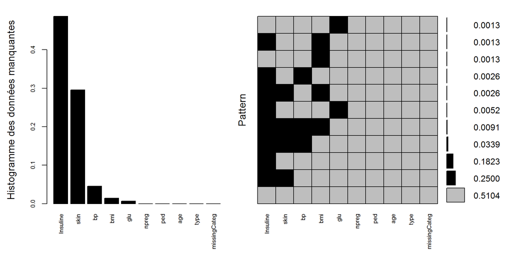

```
##
##  Variables sorted by number of missings:
##      Variable       Count
##      Insuline 0.486979167
##          skin 0.295572917
##            bp 0.045572917
##           bmi 0.014322917
##           glu 0.006510417
##         npreg 0.000000000
##           ped 0.000000000
##           age 0.000000000
##          type 0.000000000
##  missingCateg 0.000000000
```

```r
aggr_plot <- aggr(data, col=c('grey','black'), numbers=TRUE, sortVars=TRUE, labels=names(data), cex.axis=.7, gap=3, ylab=c("Histogramme des données manquantes","Pattern"))
```

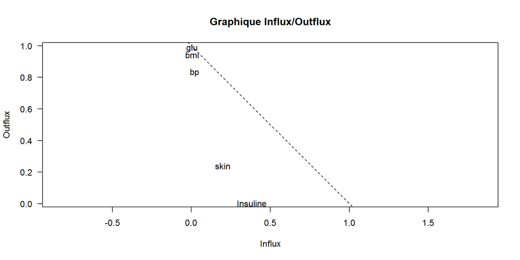

|  | influx | outflux |
| --- | --- | --- |
| glu | 0.005018821 | 0.986196319 |
| bp | 0.020388959 | 0.831288344 |
| skin | 0.200439147 | 0.239263804 |
| Insuline | 0.382685069 | 0.003067485 |
| bmi | 0.005646173 | 0.943251534 |

```r
fluxplot(data[,2:6], main="Graphique Influx/Outflux")[2:3]
```

```r
par(mfrow=c(1,2))
print("Nombre de patterns si Insuline manquant")
```

```
## [1] "Nombre de patterns si Insuline manquant"
```

```r
sum(md.pattern(data[,2:6], plot =F)[, "Insuline"]== 0)
```

```
## [1] 8
```

```r
print("Nombre de patterns si skin manquant")
```

```
## [1] "Nombre de patterns si skin manquant"
```

```r
sum(md.pattern(data[,2:6], plot =F)[,"skin"]== 0)
```

```
## [1] 4
```

```r
rm(aggr_plot)
```

- L’hypothèse MCAR semble infirmée au regard des distributions des variables Insuline et Skin comparées aux variables complètes, npreg, age et ped. A ce stade, l’hypothèse d’ignorabilité du mécanisme peut par ailleurs être maintenue. L’analyse de sensibilité nous permettra de la valider.

Nous pouvons enfin admettre que les mécanismes des variables “Insuline” et “skin” sont proches.

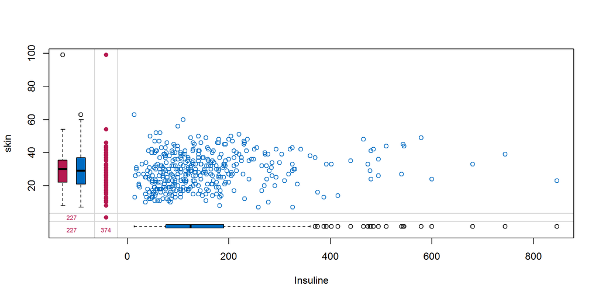

```r
par(mfrow=c(1,1))

#Distributions marginales des variables Insuline, Skin et bp avec les autres variables incomplètes
marginplot(data[c(5,4)], col = mdc(1:2, trans = FALSE), cex.numbers = .6)
```

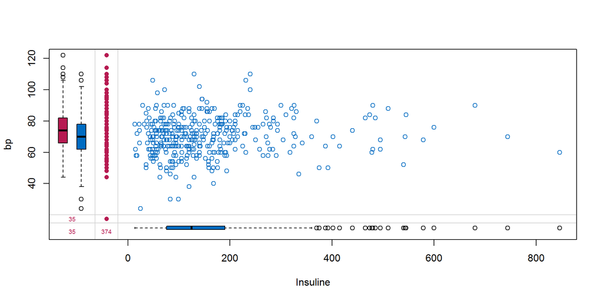

```r
marginplot(data[c(5,3)], col = mdc(1:2, trans = FALSE), cex.numbers = .6)
```

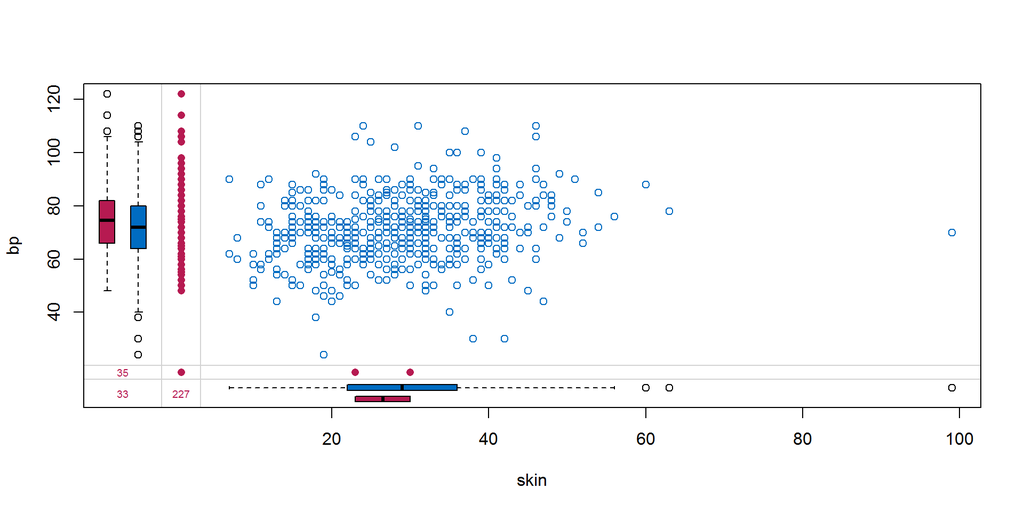

```r
marginplot(data[c(4,3)], col = mdc(1:2, trans = FALSE), cex.numbers = .6)
```

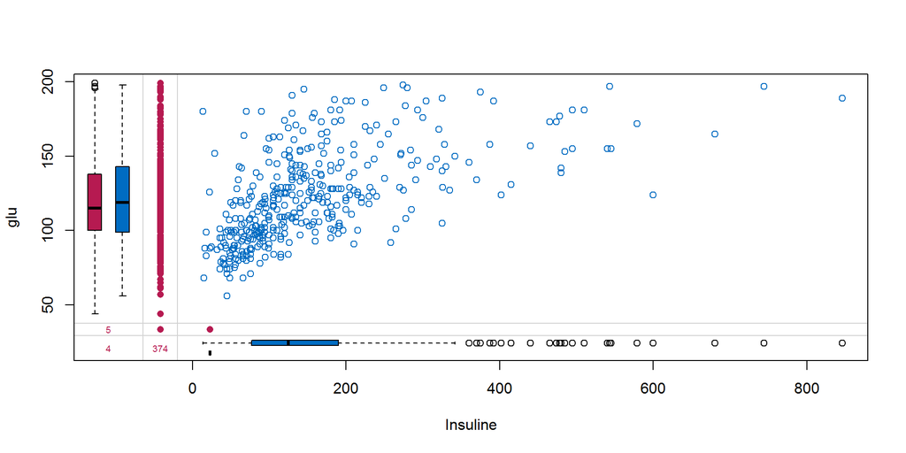

```r
marginplot(data[c(5,2)], col = mdc(1:2, trans = FALSE), cex.numbers = .6)
```

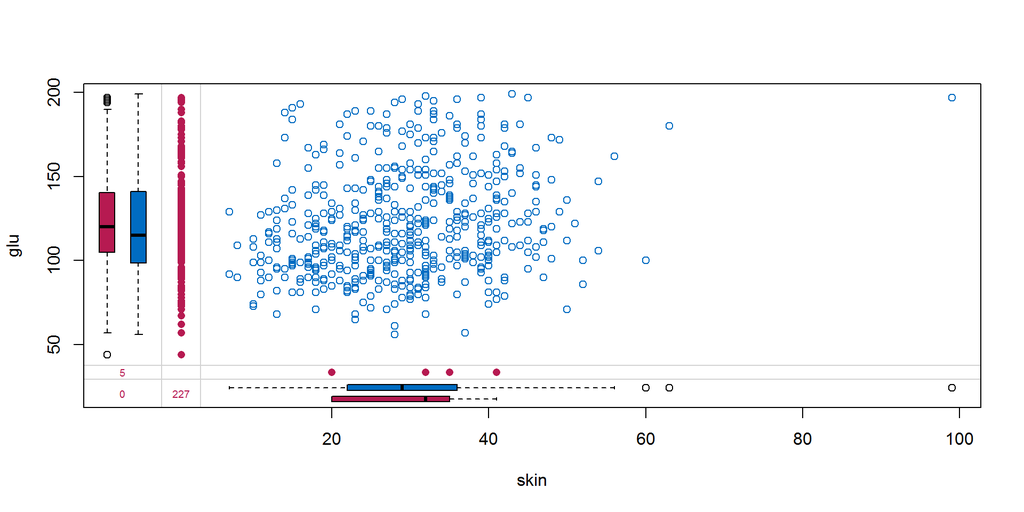

```r
marginplot(data[c(4,2)], col = mdc(1:2, trans = FALSE), cex.numbers = .6)
```

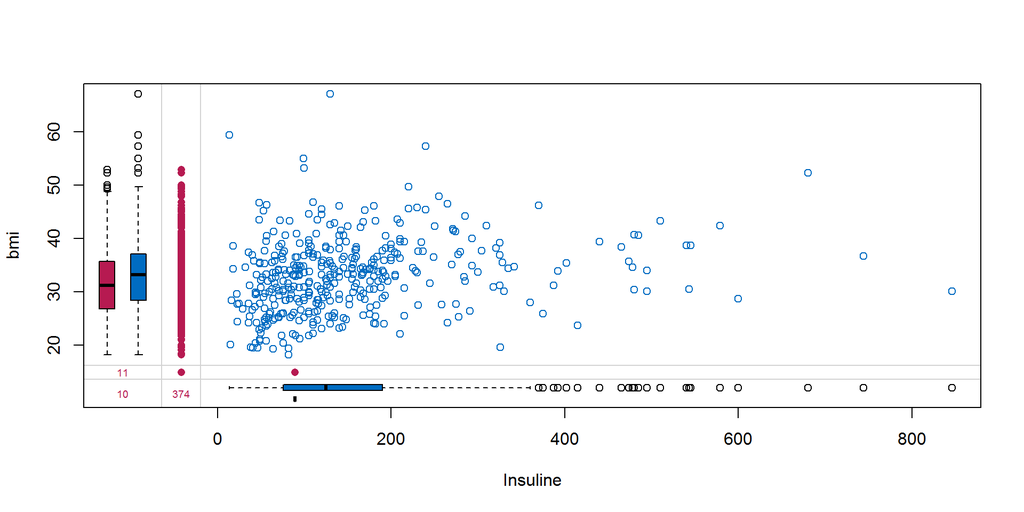

```r
marginplot(data[c(5,6)], col = mdc(1:2, trans = FALSE), cex.numbers = .6)
```

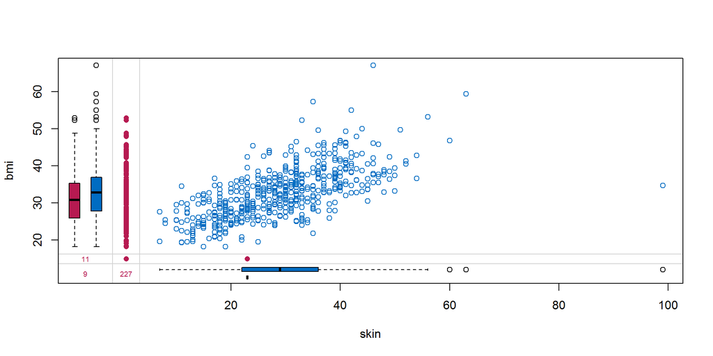

```r
marginplot(data[c(4,6)], col = mdc(1:2, trans = FALSE), cex.numbers = .6)
```

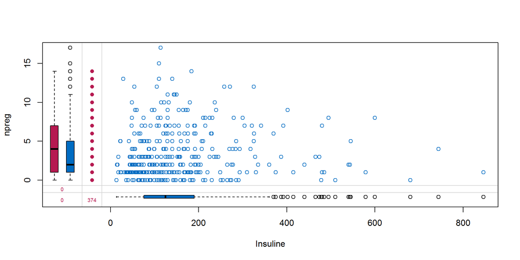

```r
#Distributions marginales des mêmes variables avec les variables complètes
marginplot(data[c(5,1)], col = mdc(1:2, trans = FALSE), cex.numbers = .6)
```

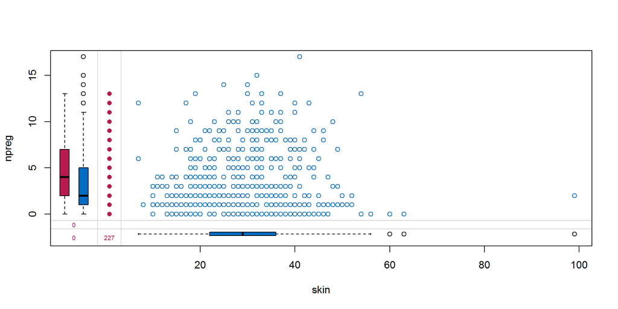

```r
marginplot(data[c(4,1)], col = mdc(1:2, trans = FALSE), cex.numbers = .6)
```

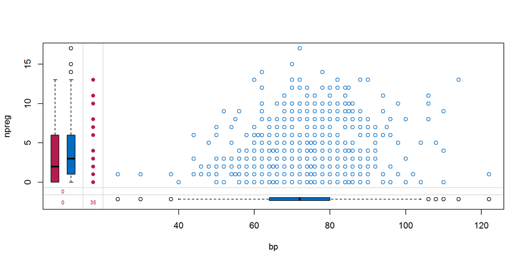

```r
marginplot(data[c(3,1)], col = mdc(1:2, trans = FALSE), cex.numbers = .6)
```

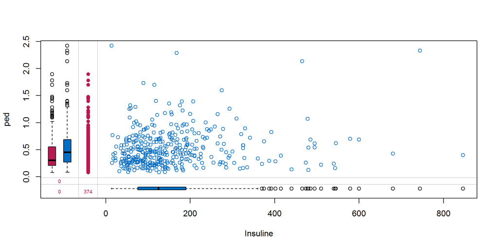

```r
marginplot(data[c(5,7)], col = mdc(1:2, trans = FALSE), cex.numbers = .6)
```

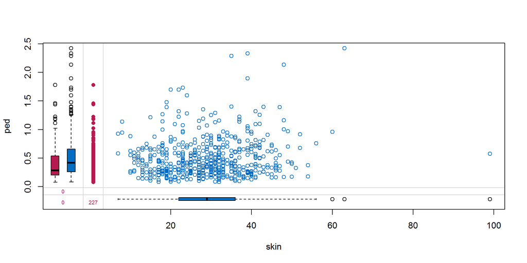

```r
marginplot(data[c(4,7)], col = mdc(1:2, trans = FALSE), cex.numbers = .6)
```

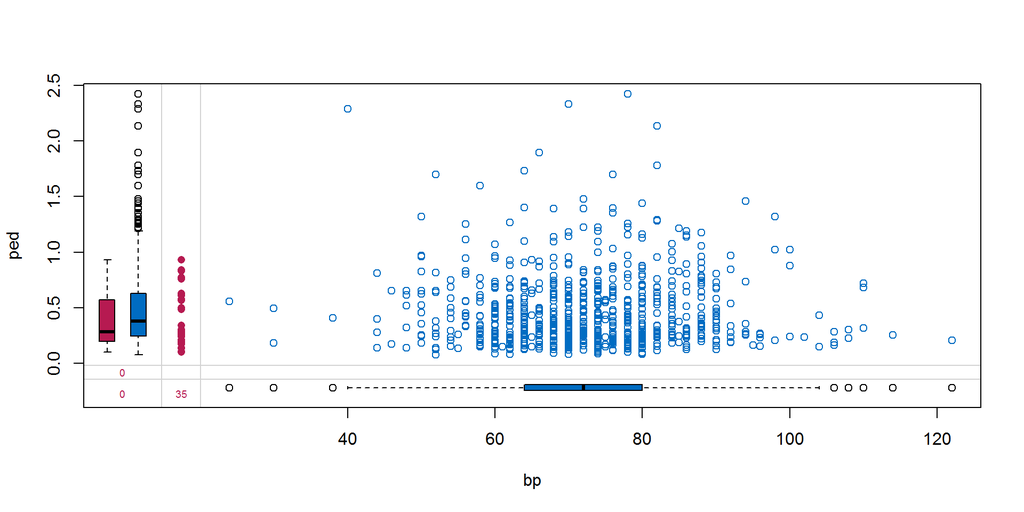

```r
marginplot(data[c(3,7)], col = mdc(1:2, trans = FALSE), cex.numbers = .6)
```

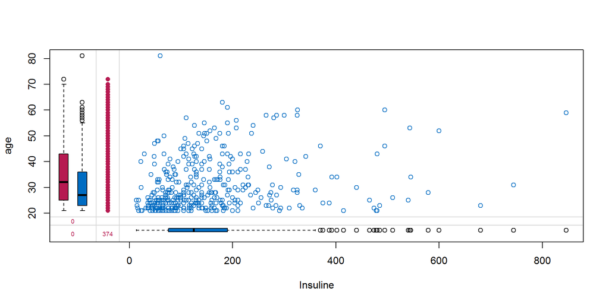

```r
marginplot(data[c(5,8)],col = mdc(1:2, trans = FALSE), cex.numbers = .6)
```

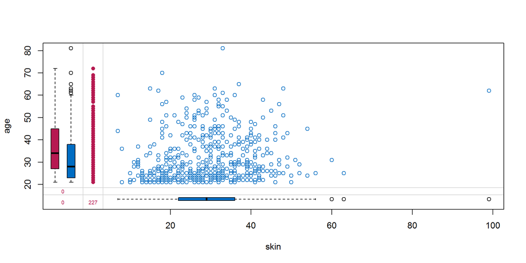

```r
marginplot(data[c(4,8)],col = mdc(1:2, trans = FALSE), cex.numbers = .6)
```

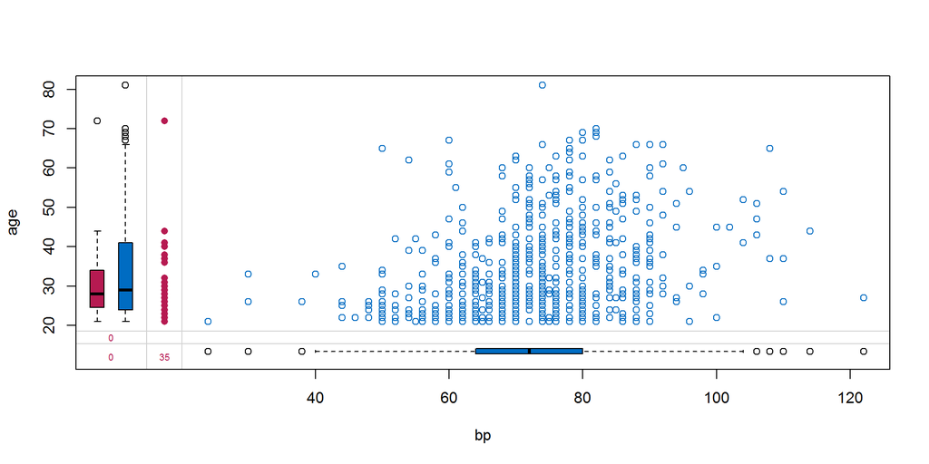

```r
marginplot(data[c(3,8)],col = mdc(1:2, trans = FALSE), cex.numbers = .6)
```

### 3. Imputations

#### 3.1 Imputations avec MICE

#### 3.1.1 Imputations simples

Dans un premier temps on traite les valeurs manquantes par imputation simple avec le package MICE : - par le biais de la méthode PMM (predictive mean matching), - puis au moyen d’une régression linéaire - non bayésienne - stochastique.

A priori, ces imputations ne seront pas conservées en raison de la sensibilité à la spécification du modèle (pour la méthode paramétrique) et du biais souvent généré par la méthode PMM (semi paramétrique).

##### 3.1.2 Imputations multiples

https://datascienceplus.com/imputing-missing-data-with-r-mice-package/

Nous recourons au cours d’une première étape à l’imputation multiple au moyen des méthodes Joint Modeling puis Fully Conditionnal Specification.

```r
#JM
imp.mi.jm <- mice(data, m=5, method='norm',seed=111119, print=F)
#FCS
imp.mi.fcs <- mice(data, m=5, seed=111119, print = F)
```

#### 3.1.3 Analyses des distributions

- Analyse des distributions des variables observées et imputées pour les imputations simples

Les graphiques montrent que les imputations par régression linéaire stochastique comportent des valeurs aberrantes, négatives pour l’épaisseur de peau et le taux d’insuline.

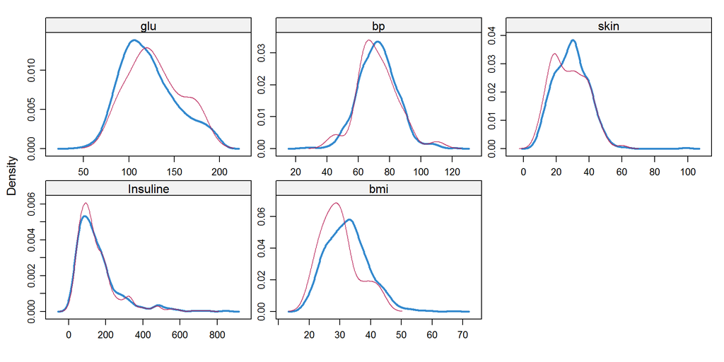

```r
#Imputations  simples
#PMM
#xyplot(imp.si.pmm,type ~ npreg + glu + bp + skin + Insuline + bmi +  ped + age, pch=18,cex=1)
densityplot(imp.si.pmm)
```

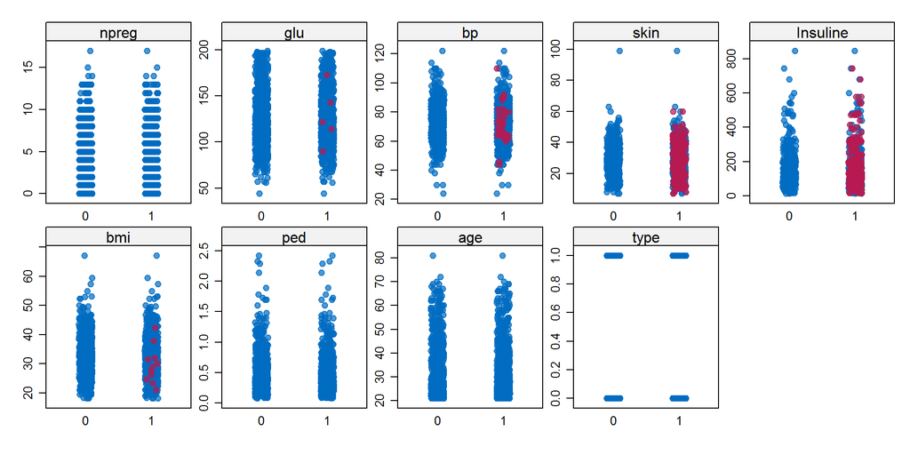

```r
stripplot(imp.si.pmm, pch = 20, cex = 1.2)
```

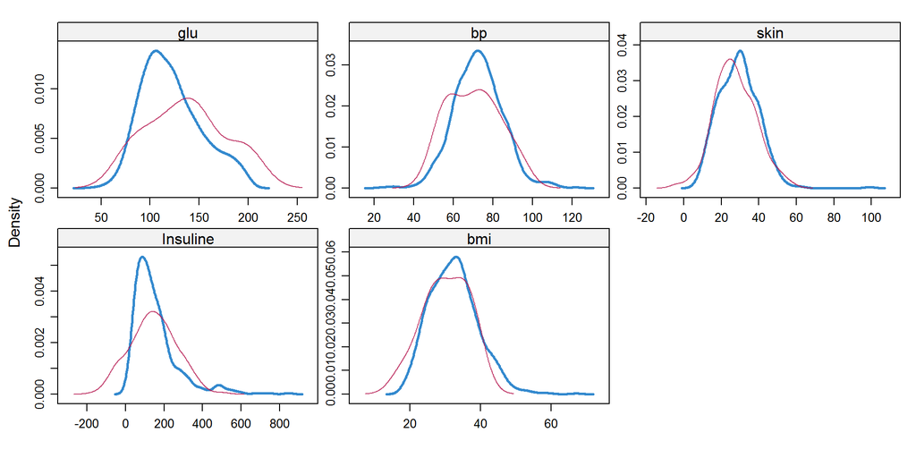

```r
#Normales
#xyplot(imp.si.norm,type ~ npreg + glu + bp + Insuline + skin + bmi +  ped + age, pch=18,cex=1)
densityplot(imp.si.norm)
```

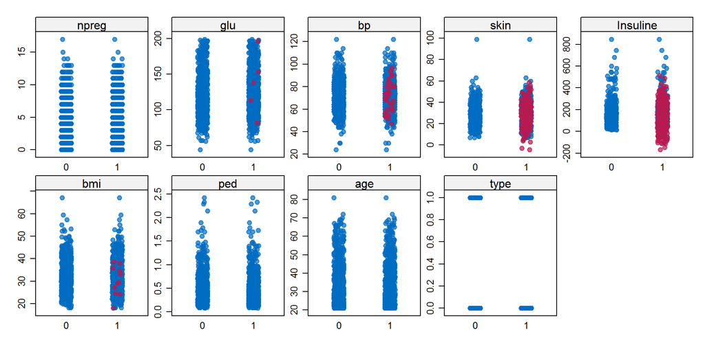

```r
stripplot(imp.si.norm, pch = 20, cex = 1.2)
```

* Analyse des distributions des variables observées et imputées pour les imputations multiples

A nouveau, certaines imputations ne sont pas plausibles : avec le modèle joint les graphiques montrent des valeurs aberrantes pour l’épaisseur de peau et le taux d’insuline.

S’agissant de la méthode FCS, les distributions des variables glu et bmi présentent des profils très divergents pour chacune des imputations.

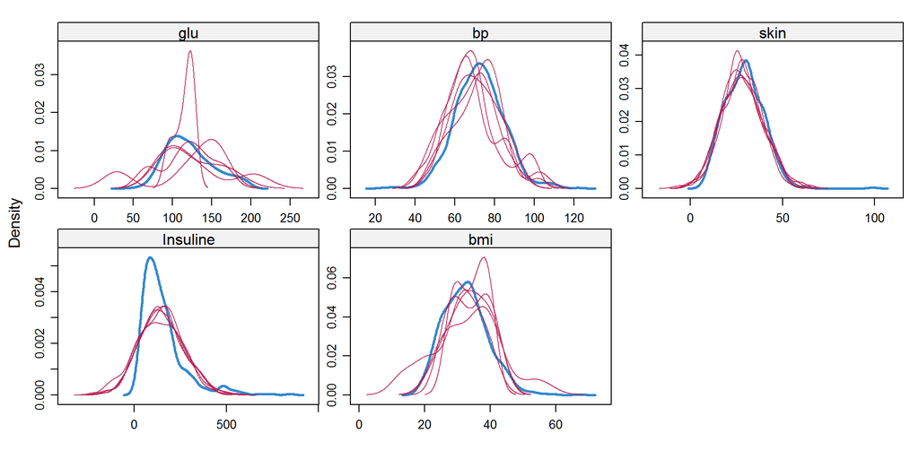

```r
#Imputations multiples
#JM
#xyplot(imp.si.pmm,type ~ npreg + glu + bp + skin + Insuline + bmi +  ped + age, pch=18,cex=1)
densityplot(imp.mi.jm)
```

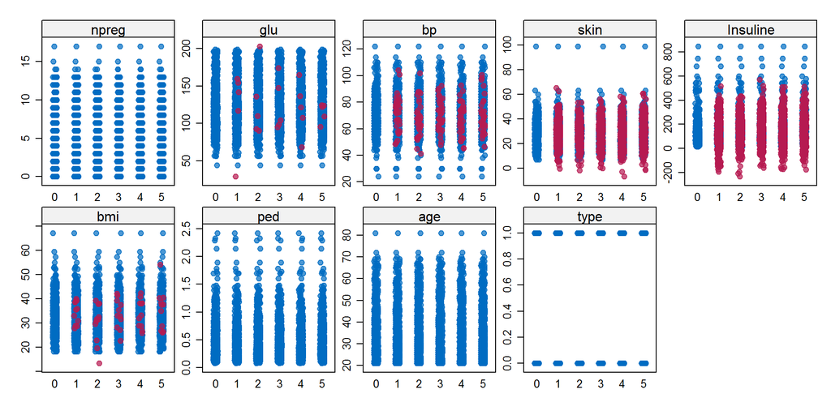

```r
stripplot(imp.mi.jm, pch = 20, cex = 1.2)
```

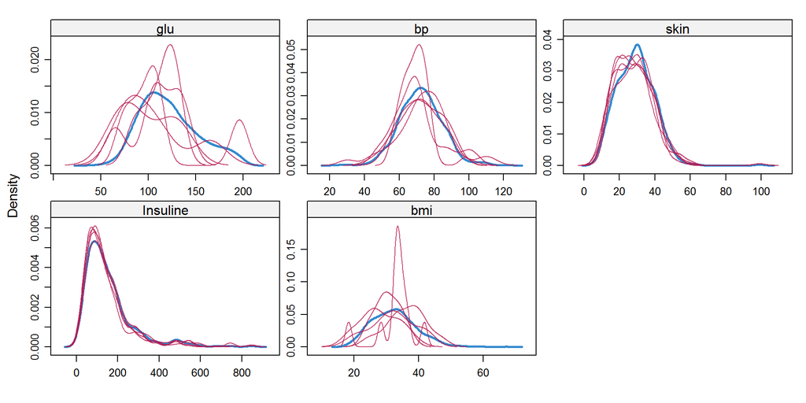

```r
#FCS
#xyplot(imp.si.norm,type ~ npreg + glu + bp + Insuline + skin + bmi +  ped + age, pch=18,cex=1)
densityplot(imp.mi.fcs, )
```

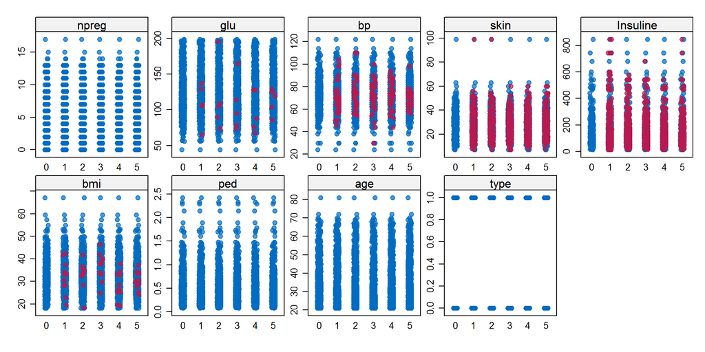

```r
stripplot(imp.mi.fcs, pch = 20, cex = 1.2)
```

#### 3.2 Imputation multiple par les méthodes d’analyse factorielle avec MIPCA

- Détermination de la dimension de l’espace de projection

big différence! Les résultats sont meilleur avec 5

Peut être utilser 4

#### 3.3.1 Multiple Imputation with Bayesian method

En changeant le nb de dimensions : de 1 à 5 le résultat est meilleur Pb pour la variabble ped mais peu d’individus concernés => ped>1.5

#### 3.3.2 Multiple Imputation with Bayesian method et EM

=> pas vraiment d’améliorations

```r
res.over_EMBayes_Pima1<-Overimpute(res.EMBayesMIPCA_Pima1)
```

[output not shown]

#### 3.3.3 Multiple Imputation with Boost method

Le résultat semble meilleur

```r
## Diagnostics
res.overBoot_Pima1<-Overimpute(res.EMBootMIPCA_Pima1)
```

[output not shown]

#### 3.3.4 Multiple Imputation with MIPCA Boost method

Le obtenu par boostrap et method= “EM” semble le meilleur résultat

```r
## Diagnostics
res.overEMBoot_Pima1<-Overimpute(res.EMBootMIPCA_Pima1)
```

[figure not shown]

```r
## Diagnostics
plot(res.EMBootMIPCA_Pima1)
```

### 4. Modélisation de la variable réponse

A partir des données complétés. Le modèle de la variable réponse: “Individus diabétique” (variable “type” : Yes/No) est un modèle logit. Regression linéaire généralisé sur les variables explicatives: npreg + glu + bp + skin + bmi + ped + age

Regression on the multiply imputed data set and pooling with mice

```r
#dataPima<-data_Pima1[,1:maxDim] #dataImp
#mi<-res.BayesMIPCA_Pima1

#on reprend les données obtenues par la méhode MIPCA obtenu par boostrp et méthode EM  (3.3.4 Multiple Imputation with MIPCA Boost method)
mi.res<-res.EMBootMIPCA_Pima1

imp_Pima1<-prelim(res.mi=mi.res,X=dataPima)#creating a mids object

#MICE: with.mids Evaluate an expression in multiple imputed datasets

fit_m_sature <- with(data=imp_Pima1,exp=glm(type ~ npreg + glu + bp + skin + Insuline + bmi +  ped + age,family=binomial(link="logit")))
#equivalent d'appeler  glm.mids : fit_Pima1_m1 & fit_m_sature même chose (on obitent les mm coeff mm modele)
#fit_m_sature <- glm.mids(type ~ npreg + glu + bp + skin + bmi + Insuline + ped +  age, data = imp_Pima1,family=binomial(link="logit"))

fit_m_NoInsuline <- with(data=imp_Pima1,exp=glm(type ~ npreg + glu + bp + skin + bmi +  ped + age,family=binomial(link="logit")))
#fit_m_NoInsuline <- glm.mids(type ~ npreg + glu + bp + skin + bmi + ped +  age, data = imp_Pima1,family=binomial(link="logit"))
```

- Summary

```r
#pooling et summary
res.pool_m_sature<-pool(fit_m_sature);
summary(res.pool_m_sature)#pooling
```

|  | estimate | std.error | statistic | df | p.value |
| --- | --- | --- | --- | --- | --- |
| (Intercept) | -7.931900644 | 0.890157496 | -8.910671 | 456.4936 | 0.000000e+00 |
| npreg | 0.133791777 | 0.035035017 | 3.818802 | 688.9014 | 1.461957e-04 |
| glu | 0.029699816 | 0.004467097 | 6.648572 | 611.4083 | 6.566614e-11 |
| bp | -0.019571561 | 0.008736712 | -2.240152 | 535.8247 | 2.549021e-02 |
| skin | 0.032321537 | 0.013432563 | 2.406208 | 309.9570 | 1.670417e-02 |
| Insuline | 0.003179239 | 0.001091720 | 2.912136 | 331.5947 | 3.832929e-03 |
| bmi | 0.057967391 | 0.021403228 | 2.708348 | 471.2250 | 7.007927e-03 |
| ped | 0.884127410 | 0.306359870 | 2.885911 | 731.0994 | 4.017813e-03 |
| age | 0.018530863 | 0.010295236 | 1.799945 | 709.4587 | 7.229398e-02 |

```r
res.pool_m_NoInsuline<-pool(fit_m_NoInsuline);
summary(res.pool_m_NoInsuline)#pooling
```

|  | estimate | std.error | statistic | df | p.value |
| --- | --- | --- | --- | --- | --- |
| (Intercept) | -8.54274311 | 0.870853535 | -9.809621 | 457.0005 | 0.000000000 |
| npreg | 0.10799326 | 0.033222353 | 3.250621 | 737.1386 | 0.001203860 |
| glu | 0.03765211 | 0.003679869 | 10.231916 | 739.4591 | 0.000000000 |
| bp | -0.01831101 | 0.008565258 | -2.137824 | 548.1335 | 0.032972686 |
| skin | 0.02900220 | 0.013477809 | 2.151848 | 287.7521 | 0.032241208 |
| bmi | 0.06335315 | 0.021547619 | 2.940146 | 435.3129 | 0.003455338 |
| ped | 0.88888497 | 0.301083178 | 2.952290 | 749.7843 | 0.003252756 |
| age | 0.02035530 | 0.010023973 | 2.030662 | 736.2558 | 0.042648218 |

- Comparaison Modele saturé avec / sans Insuline Component pvalue is the P-value of testing whether the model fit1 is statistically different from the smaller fit0. https://stefvanbuuren.name/mice/reference/pool.html

```r
#comp
stat_wald<- pool.compare(fit_m_sature, fit_m_NoInsuline, method = "wald")
stat_wald$p
```

```
##             [,1]
## [1,] 0.003679994
```

```r
stat_likelihood<- pool.compare(fit_m_sature, fit_m_NoInsuline, method = "likelihood")
stat_likelihood$p
```

```
## [1] 0.004047293
```

Petite p-value pour les deux tests => on conserve le pus grand modele (a verifier si s’interprète bien ainsi?)

- Anova => semble fonctionner…

```r
anova(fit_m_sature,fit_m_NoInsuline)
```

```
##    test statistic df1     df2 df.com     p.value       riv
##  1 ~~ 2  8.480537   1 408.414    759 0.003786555 0.4795771
```

Petite p-value => on rejette l’hypothése H0 de nullité du coefficient insuline. on garde le plus grand modèle donc. Ce qui est conforme aux p-value du summary

```r
fit_m_NoAge <- with(data=imp_Pima1,exp=glm(type ~ npreg + glu + bp + skin + Insuline + bmi +  ped ,family=binomial(link="logit")))
fit_m_NoSkin <- with(data=imp_Pima1,exp=glm(type ~ npreg + glu + bp  + Insuline + bmi +  ped + age ,family=binomial(link="logit")))
fit_m_NoBp <- with(data=imp_Pima1,exp=glm(type ~ npreg + glu + skin + Insuline + bmi +  ped + age,family=binomial(link="logit")))
fit_m_NoBmi <- with(data=imp_Pima1,exp=glm(type ~ npreg + glu + skin + Insuline + bp +  ped + age,family=binomial(link="logit")))
fit_m_Noglu <- with(data=imp_Pima1,exp=glm(type ~ npreg + bp + skin + Insuline + bmi +  ped + age,family=binomial(link="logit")))
fit_m_NoNpreg <- with(data=imp_Pima1,exp=glm(type ~ glu + bp + skin + Insuline + bmi +  ped + age,family=binomial(link="logit")))
```

```r
#no Age
stat_wald<- pool.compare(fit_m_sature, fit_m_NoAge, method = "wald")
stat_wald$p
```

```
##            [,1]
## [1,] 0.07187668
```

```r
stat_likelihood<- pool.compare(fit_m_sature, fit_m_NoAge, method = "likelihood")
stat_likelihood$p
```

```
## [1] 0.06671843
```

```r
#no Skin
stat_wald<- pool.compare(fit_m_sature, fit_m_NoSkin, method = "wald")
stat_wald$p
```

```
##            [,1]
## [1,] 0.01635133
```

```r
stat_likelihood<- pool.compare(fit_m_sature, fit_m_NoSkin, method = "likelihood")
stat_likelihood$p
```

```
## [1] 0.02278897
```

```r
# No bp
stat_wald<- pool.compare(fit_m_sature, fit_m_NoBp, method = "wald")
stat_wald$p
```

```
##            [,1]
## [1,] 0.02514725
```

```r
stat_likelihood<- pool.compare(fit_m_sature, fit_m_NoBp, method = "likelihood")
stat_likelihood$p
```

```
## [1] 0.006649643
```

```r
#no bmi
stat_wald<- pool.compare(fit_m_sature, fit_m_NoBmi, method = "wald")
stat_wald$p
```

```
##             [,1]
## [1,] 0.006817402
```

```r
stat_likelihood<- pool.compare(fit_m_sature, fit_m_NoBmi, method = "likelihood")
stat_likelihood$p
```

```
## [1] 0.01172844
```

```r
#no glu
stat_wald<- pool.compare(fit_m_sature, fit_m_Noglu, method = "wald")
stat_wald$p
```

```
##              [,1]
## [1,] 3.194045e-11
```

```r
stat_likelihood<- pool.compare(fit_m_sature, fit_m_Noglu, method = "likelihood")
stat_likelihood$p
```

```
## [1] 3.330669e-16
```

```r
#no npreg
stat_wald<- pool.compare(fit_m_sature, fit_m_NoNpreg, method = "wald")
stat_wald$p
```

```
##              [,1]
## [1,] 0.0001344596
```

```r
stat_likelihood<- pool.compare(fit_m_sature, fit_m_NoNpreg, method = "likelihood")
stat_likelihood$p
```

```
## [1] 6.415294e-05
```

Choix du modèle saturé A la limite on pourrait enlever la variable âge.

Pour utiliser les techniques de choix de modèles classiques, on a besoin d’avoir un dataFrame des données imputés. Or celà ne semble pas possible. J’ai tout de même laissé cette partie construite à partir du dataframe : res.imputePCA de MIPCA (res.EMBootMIPCA_Pima1$res.imputePCA)  
Je serai d’avis à le supprimer si on ne trouve pas un moyen d’obtenir un dataFrame des données imputés. Ce qui ne me semble pas possible. On a le même problème pour l’analyse PCA

Dans la vignette du package MissMDA ils utilisent : imputePCA pour faire une pca

#### Choix du modèle - Utilisation de regsubsets

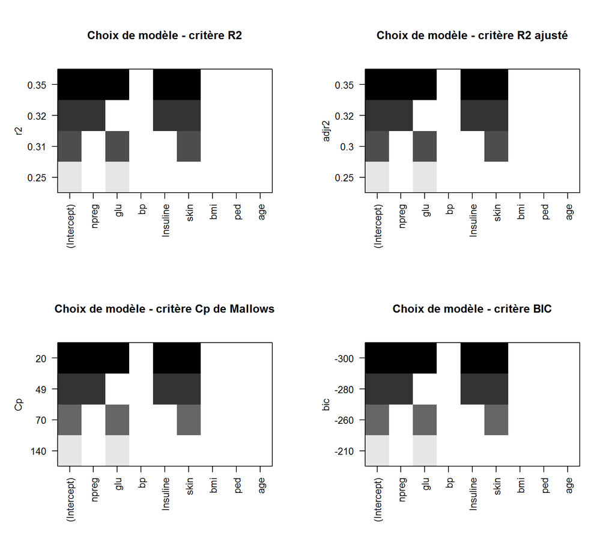

#### Choix du modèle - méthode step du package MASS à partir du modèle saturé

```r
m_sature = glm(formula = type ~ (npreg + glu + bp + skin + Insuline + bmi +  ped + age),  family = binomial(link="logit"),  data = dataFramePima)
summary(m_sature)
```

```
##
## Call:
## glm(formula = type ~ (npreg + glu + bp + skin + Insuline + bmi +
##     ped + age), family = binomial(link = "logit"), data = dataFramePima)
##
## Deviance Residuals:
##     Min       1Q   Median       3Q      Max
## -3.7077  -0.6562  -0.3389   0.6336   2.6553
##
## Coefficients:
##              Estimate Std. Error z value Pr(>|z|)
## (Intercept) -7.439466   0.817377  -9.102  < 2e-16 ***
## npreg        0.146155   0.035220   4.150 3.33e-05 ***
## glu          0.022407   0.004861   4.610 4.03e-06 ***
## bp          -0.021911   0.008423  -2.601  0.00928 **
## skin         0.057661   0.014053   4.103 4.08e-05 ***
## Insuline     0.006255   0.001322   4.730 2.24e-06 ***
## bmi          0.034502   0.021688   1.591  0.11165
## ped          0.869441   0.305506   2.846  0.00443 **
## age          0.021077   0.010364   2.034  0.04198 *
## ---
## Signif. codes:  0 '***' 0.001 '**' 0.01 '*' 0.05 '.' 0.1 ' ' 1
##
## (Dispersion parameter for binomial family taken to be 1)
##
##     Null deviance: 993.48  on 767  degrees of freedom
## Residual deviance: 662.39  on 759  degrees of freedom
## AIC: 680.39
##
## Number of Fisher Scoring iterations: 5
```

#### Choix du modèle - Méthode progressive - step backward-forward à partir de m_sature

- Critère AIC
- Critère BIC

##### Choix du modèle - Modèle obtenu

```r
modele_step_BwdFwd_AIC<-glm(formula = type ~ (npreg + glu + bp + skin + Insuline + bmi + ped + age), family = binomial, data = dataFramePima)
summary(modele_step_BwdFwd_AIC)
```

```
##
## Call:
## glm(formula = type ~ (npreg + glu + bp + skin + Insuline + bmi +
##     ped + age), family = binomial, data = dataFramePima)
##
## Deviance Residuals:
##     Min       1Q   Median       3Q      Max
## -3.7077  -0.6562  -0.3389   0.6336   2.6553
##
## Coefficients:
##              Estimate Std. Error z value Pr(>|z|)
## (Intercept) -7.439466   0.817377  -9.102  < 2e-16 ***
## npreg        0.146155   0.035220   4.150 3.33e-05 ***
## glu          0.022407   0.004861   4.610 4.03e-06 ***
## bp          -0.021911   0.008423  -2.601  0.00928 **
## skin         0.057661   0.014053   4.103 4.08e-05 ***
## Insuline     0.006255   0.001322   4.730 2.24e-06 ***
## bmi          0.034502   0.021688   1.591  0.11165
## ped          0.869441   0.305506   2.846  0.00443 **
## age          0.021077   0.010364   2.034  0.04198 *
## ---
## Signif. codes:  0 '***' 0.001 '**' 0.01 '*' 0.05 '.' 0.1 ' ' 1
##
## (Dispersion parameter for binomial family taken to be 1)
##
##     Null deviance: 993.48  on 767  degrees of freedom
## Residual deviance: 662.39  on 759  degrees of freedom
## AIC: 680.39
##
## Number of Fisher Scoring iterations: 5
```

```r
AIC(modele_step_BwdFwd_AIC)
```

```
## [1] 680.3939
```

```r
BIC(modele_step_BwdFwd_AIC)
```

```
## [1] 722.188
```

```r
m_StepBwdFwd_BIC<-glm(formula = type ~ (npreg + glu + skin + Insuline + ped),family = binomial, data = dataFramePima)
summary(m_StepBwdFwd_BIC)
```

```
##
## Call:
## glm(formula = type ~ (npreg + glu + skin + Insuline + ped), family = binomial,
##     data = dataFramePima)
##
## Deviance Residuals:
##     Min       1Q   Median       3Q      Max
## -3.7362  -0.6453  -0.3441   0.6430   2.5784
##
## Coefficients:
##              Estimate Std. Error z value Pr(>|z|)
## (Intercept) -7.541485   0.625754 -12.052  < 2e-16 ***
## npreg        0.165557   0.029457   5.620 1.91e-08 ***
## glu          0.022656   0.004760   4.760 1.94e-06 ***
## skin         0.065986   0.009707   6.798 1.06e-11 ***
## Insuline     0.006323   0.001301   4.860 1.17e-06 ***
## ped          0.909031   0.296921   3.062   0.0022 **
## ---
## Signif. codes:  0 '***' 0.001 '**' 0.01 '*' 0.05 '.' 0.1 ' ' 1
##
## (Dispersion parameter for binomial family taken to be 1)
##
##     Null deviance: 993.48  on 767  degrees of freedom
## Residual deviance: 672.23  on 762  degrees of freedom
## AIC: 684.23
##
## Number of Fisher Scoring iterations: 5
```

```r
AIC(m_StepBwdFwd_BIC)
```

```
## [1] 684.2259
```

```r
BIC(m_StepBwdFwd_BIC)
```

```
## [1] 712.0887
```

Avec le critère AIC on obtient le modèle saturé Avec le critère BIC : glm(npreg + glu + skin + Insuline + ped)

### 5. Conclusion

Intérêt : Les données Pima sont très utilsées (cf. Kaggle) pour autant il ne semble pas qu’un modèle d’inputation ait été utilisé. Bien souvent les données manquantes sont supprimés ou bien imputatikon simple par moyenne.

## Annexes

### Annexe 1 : Analyse PCA - comparaison aux données non traitées

- PCA sur les données complétées par MIPCA

```
##
## Call:
## PCA(X = dataFramePima, quali.sup = 8:9, graph = FALSE)
##
##
## Eigenvalues
##                        Dim.1   Dim.2   Dim.3   Dim.4   Dim.5   Dim.6
## Variance               2.315   1.399   1.123   0.921   0.779   0.233
## % of var.             33.077  19.981  16.041  13.152  11.130   3.331
## Cumulative % of var.  33.077  53.059  69.100  82.252  93.383  96.713
##                        Dim.7
## Variance               0.230
## % of var.              3.287
## Cumulative % of var. 100.000
##
## Individuals (the 10 first)
##              Dist    Dim.1    ctr   cos2    Dim.2    ctr   cos2    Dim.3
## 1        |  1.520 |  1.226  0.084  0.650 | -0.375  0.013  0.061 |  0.246
## 2        |  2.002 | -1.646  0.152  0.676 |  0.544  0.028  0.074 | -0.650
## 3        |  3.419 |  0.581  0.019  0.029 | -2.738  0.698  0.641 |  1.151
## 4        |  1.946 | -1.643  0.152  0.713 |  0.123  0.001  0.004 | -0.375
## 5        |  6.363 |  1.416  0.113  0.050 | -0.450  0.019  0.005 | -4.477
## 6        |  1.639 | -1.173  0.077  0.512 | -0.404  0.015  0.061 |  1.016
## 7        |  2.426 | -1.550  0.135  0.408 |  0.866  0.070  0.127 | -0.877
## 8        |  2.587 | -0.215  0.003  0.007 |  1.743  0.283  0.454 |  1.382
## 9        |  4.520 |  2.839  0.453  0.395 | -2.393  0.533  0.280 | -0.033
## 10       |  4.084 |  2.841  0.454  0.484 |  2.637  0.647  0.417 |  1.031
##             ctr   cos2
## 1         0.007  0.026 |
## 2         0.049  0.105 |
## 3         0.154  0.113 |
## 4         0.016  0.037 |
## 5         2.324  0.495 |
## 6         0.120  0.384 |
## 7         0.089  0.131 |
## 8         0.221  0.285 |
## 9         0.000  0.000 |
## 10        0.123  0.064 |
##
## Variables
```

[output cut: 25 more lines]

```
## age 27   |  0.517 | -0.198  0.147 -0.752 |  0.010  0.000  0.051 | -0.176
## age 28   |  0.343 |  0.022  0.004  0.086 |  0.142  0.171  0.726 | -0.261
## age 29   |  0.492 |  0.346  0.495  1.248 |  0.019  0.002  0.089 | -0.073
## age 30   |  0.389 | -0.163  0.175 -0.497 | -0.100  0.066 -0.392 |  0.032
##            cos2 v.test
## age 21    0.257 -4.697 |
## age 22    0.314 -4.752 |
## age 23    0.440 -3.413 |
## age 24    0.506 -3.672 |
## age 25    0.829 -6.243 |
## age 26    0.543 -3.520 |
## age 27    0.116 -0.961 |
## age 28    0.581 -1.492 |
## age 29    0.022 -0.377 |
## age 30    0.007  0.140 |
```

```
##
## Call:
## PCA(X = dataPimaMASS, quali.sup = 8, graph = FALSE)
##
##
## Eigenvalues
##                        Dim.1   Dim.2   Dim.3   Dim.4   Dim.5   Dim.6
## Variance               2.316   1.500   1.007   0.800   0.717   0.349
## % of var.             33.092  21.434  14.386  11.430  10.242   4.984
## Cumulative % of var.  33.092  54.526  68.912  80.342  90.584  95.568
##                        Dim.7
## Variance               0.310
## % of var.              4.432
## Cumulative % of var. 100.000
##
## Individuals (the 10 first)
##           Dist    Dim.1    ctr   cos2    Dim.2    ctr   cos2    Dim.3
## 1     |  1.547 | -0.964  0.075  0.389 | -0.249  0.008  0.026 | -0.577
## 2     |  3.735 |  1.663  0.224  0.198 | -2.123  0.564  0.323 |  0.219
## 3     |  2.347 |  0.618  0.031  0.069 | -0.038  0.000  0.000 | -1.859
## 4     |  3.248 |  1.446  0.170  0.198 |  2.378  0.708  0.536 | -0.914
## 5     |  2.249 | -2.006  0.327  0.796 |  0.196  0.005  0.008 | -0.576
## 6     |  2.205 |  0.865  0.061  0.154 | -1.201  0.181  0.297 | -0.609
## 7     |  1.850 | -1.135  0.104  0.376 |  0.478  0.029  0.067 | -0.586
## 8     |  3.513 | -1.326  0.143  0.143 |  0.054  0.000  0.000 |  2.053
## 9     |  3.476 |  0.995  0.080  0.082 | -2.110  0.558  0.368 | -0.317
## 10    |  2.789 |  1.411  0.162  0.256 |  1.692  0.359  0.368 |  1.291
##          ctr   cos2
## 1      0.062  0.139 |
## 2      0.009  0.003 |
## 3      0.645  0.627 |
## 4      0.156  0.079 |
## 5      0.062  0.066 |
## 6      0.069  0.076 |
## 7      0.064  0.100 |
## 8      0.787  0.342 |
## 9      0.019  0.008 |
## 10     0.311  0.214 |
##
## Variables
```

[output cut: 9 more lines]

```
## npreg |
## glu   |
## bp    |
## skin  |
## bmi   |
## ped   |
## age   |
##
## Supplementary categories
##            Dist     Dim.1    cos2  v.test     Dim.2    cos2  v.test
## No    |   0.574 |  -0.536   0.872 -11.491 |  -0.009   0.000  -0.238 |
## Yes   |   1.151 |   1.075   0.872  11.491 |   0.018   0.000   0.238 |
##         Dim.3    cos2  v.test
## No     -0.156   0.074  -5.089 |
## Yes     0.314   0.074   5.089 |
```

#### 1. Choix du nombre d’axes

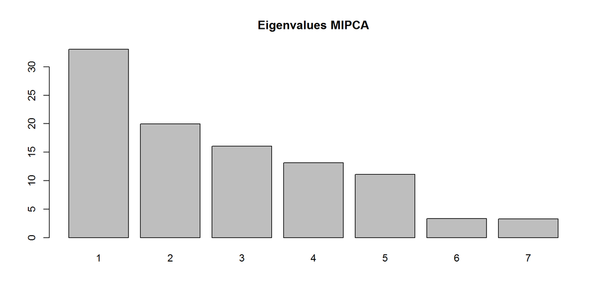

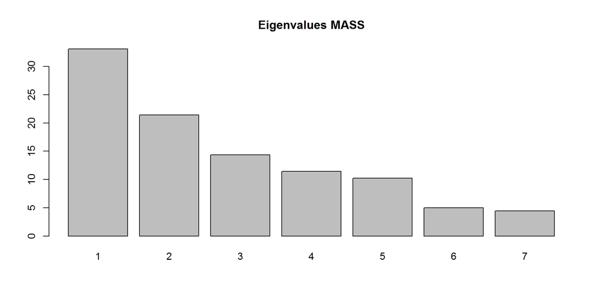